# TAE - Unit 7 - Lecture 1

GT

May 24, 2016

## Visualizing the Word

In this lecture, we’ll discuss the idea of using visualization to better understand data and to provide insights on the problem we’re addressing.

*Why visualization?*

People often say that a picture is like a thousand words.

In the same spirit, John Tukey, a major statistician at Princeton, wrote that

> “the picture-examining eye is the best finder we have of the wholly unanticipated.”

Visualizing data allows us to discern relationships, structures, distributions, outliers, patterns, behaviors, dependencies, and outcomes.

Visualization is further useful for initial data exploration, for interpreting models, and for communicating results effectively.

We’ll see how visualizations can be used to better understand data, communicate information more effectively, show the results of analytical models.

### The World Health Organization (WHO)

The World Health Organization, WHO for short, is the authority for health within the United Nations system.

It is responsible for providing leadership on global health matters, shaping the health research agenda, setting norms and standards, articulating evidence-based policy options, providing technical support to countries, and monitoring and assessing health trends.

WHO communicates information about global health in order to inform citizens, donors, policymakers, and organizations around the world.

Their primary publication is World Health Report.

Each issue focuses on a specific aspect of global health, and includes statistics and experts’ assessments. WHO also maintains an open, online repository of global health data. WHO provides some data visualizations, which helps them communicate more effectively with the public.

### What is Data Visualization ?

Data visualization is defined as a mapping of data properties to visual properties.

Data properties are usually numerical or categorical, like the mean of a variable, the maximum value of a variable, or the number of observations with a certain property.

Visual properties can be (x,y) coordinates to plot points on a graph, colors to assign labels, sizes, shapes, heights, etc.

Both types of properties are used to better understand the data, but in different ways.

To motivate the need for data visualization, let’s look at a famous example called Anscombe’s Quartet.

Each of these tables corresponds to a different data set. We have four data sets, each with two variables, x and y.

[output not shown]

Just looking at the tables of data, it’s hard to notice anything special about it. It turns out that the mean and variance of the x variable is the same for all four data sets, the mean and variance of the y variable is the same for all four data sets, and the correlation between x and y, as well as the regression equation to predict y from x, is the exact same for all four data sets.

So just by looking at data properties, we might conclude that these data sets are very similar.

But if we plot the four data sets, they’re very different.

```
y1^                                     y2^
  |                 *    *                |
  |                                       |
  |             *    *                    |           *  *
  |         *    *                        |         *       *
  |    * *                                |       *          *
  |   *   *                               |      *
  |  *                                    |     *
  +---------------------------->          +---------------------------->
                               x1                                      x2
y3^                                     y4^
  |                  *                    |                         *
  |                                       |
  |                +  *                   |      *
  |           +*                          |      *
  |      +*                               |      *
  |   *                                   |      *
  |                                       |
  +---------------------------->          +---------------------------->
                               x3                                      x4
```

These plots show the four data sets, with the x variable on the x-axis, and the y variable on the y-axis.

Visually, these data sets look very different. But without visualizing them, we might not have noticed this.

This is one example of why visualizing data can be very important.

We’ll use the **ggplot2** package in R to create data visualizations.

This package was created by Hadley Wickham, who described ggplot as

> “a plotting system for R based on the grammar of graphics, which tries to take the good parts of base and lattice graphics and none of the bad parts. It takes care of many of the fiddly details that make plotting a hassle (like drawing legends) as well as providing a powerful model of graphics that makes it easy to produce complex multi-layered graphics.”

So what do we gain from using ggplot over just making plots using the basic R functions, or what’s referred to as base R?

Well, in base R, each mapping of data properties to visual properties is its own special case.

When we create a scatter plot, or a box plot, or a histogram, we have to use a completely different function. Additionally, the graphics are composed of simple elements, like points or lines.

It’s challenging to create any sophisticated visualizations. It’s also difficult to add elements to existing plots.

But in ggplot, the mapping of data properties to visual properties is done by just adding layers to the plot. This makes it much easier to create sophisticated plots and to add to existing plots.

So what is the grammar of graphics that ggplot is based on?

All ggplot graphics consist of three elements.

1. **Data**, in a data frame.
2. **Aesthetic mapping**, which describes how variables in the data frame are mapped to graphical attributes. *Color, shape, scale, x-y axes, subsets,…*
3. **Geometric objects** determine how the data values are rendered graphically. *Points, lines, bars, boxes, etc.*

### Basic Scatterplots Using ggplot

Let’s start by reading in our data.

```r
WHO = read.csv("WHO.csv")
str(WHO)
```

```
## 'data.frame':    194 obs. of  13 variables:
##  $ Country                      : Factor w/ 194 levels "Afghanistan",..: 1 2 3 4 5 6 7 8 9 10 ...
##  $ Region                       : Factor w/ 6 levels "Africa","Americas",..: 3 4 1 4 1 2 2 4 6 4 ...
##  $ Population                   : int  29825 3162 38482 78 20821 89 41087 2969 23050 8464 ...
##  $ Under15                      : num  47.4 21.3 27.4 15.2 47.6 ...
##  $ Over60                       : num  3.82 14.93 7.17 22.86 3.84 ...
##  $ FertilityRate                : num  5.4 1.75 2.83 NA 6.1 2.12 2.2 1.74 1.89 1.44 ...
##  $ LifeExpectancy               : int  60 74 73 82 51 75 76 71 82 81 ...
##  $ ChildMortality               : num  98.5 16.7 20 3.2 163.5 ...
##  $ CellularSubscribers          : num  54.3 96.4 99 75.5 48.4 ...
##  $ LiteracyRate                 : num  NA NA NA NA 70.1 99 97.8 99.6 NA NA ...
##  $ GNI                          : num  1140 8820 8310 NA 5230 ...
##  $ PrimarySchoolEnrollmentMale  : num  NA NA 98.2 78.4 93.1 91.1 NA NA 96.9 NA ...
##  $ PrimarySchoolEnrollmentFemale: num  NA NA 96.4 79.4 78.2 84.5 NA NA 97.5 NA ...
```

We can see that we have 194 observations, or countries, and 13 different variables.

In week one, the very first plot we made in R was a scatterplot of fertility rate versus gross national income.

Let’s make this plot again, just like we did in week one.

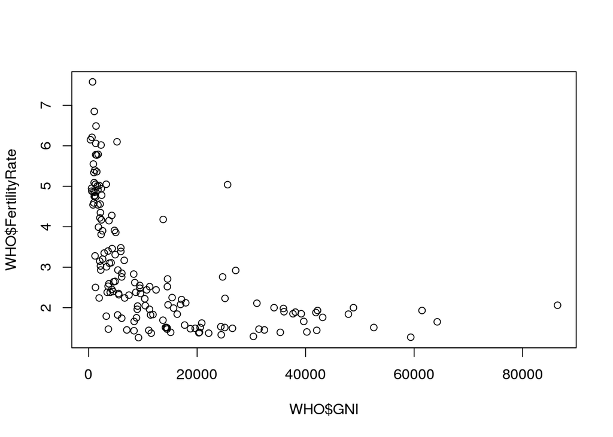

```r
plot(WHO$GNI, WHO$FertilityRate)
```

This plot shows us that a higher fertility rate is correlated with a lower income.

Now, let’s redo this scatterplot, but this time using ggplot. We’ll see how ggplot can be used to make more visually appealing and complex scatterplots.

First, we need to install and load the ggplot2 package.

```r
library(ggplot2)
```

Now, remember we need at least three things to create a plot using ggplot, data, an aesthetic mapping of variables in the data frame to visual output, and a geometric object.

So first, let’s create the ggplot object with the data and the aesthetic mapping.

```r
scatterplot = ggplot(WHO, aes(x = GNI, y = FertilityRate))
```

Now, we need to tell ggplot what geometric objects to put in the plot. We could use bars, lines, points, or something else.

This is a big difference between ggplot and regular plotting in R. You can build different types of graphs by using the same ggplot object.

So first, let’s just create a straightforward scatterplot.

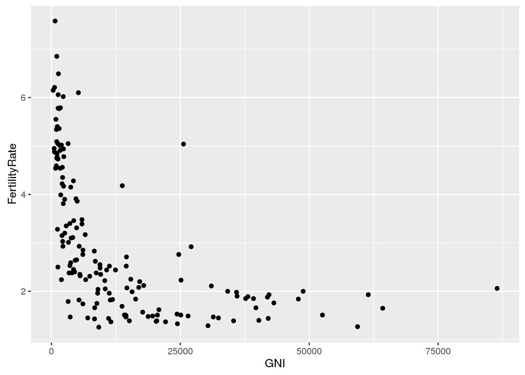

```r
scatterplot + geom_point()
```

You should see a new plot in the Graphics window that looks similar to our original plot, but there are already a few nice improvements.

One is that we don’t have the data set name with a dollar sign in front of the label on each axis, just the variable name. Another is that we have these nice grid lines in the background and solid points that pop out from the background.

We could have made a line graph just as easily by changing point to line.

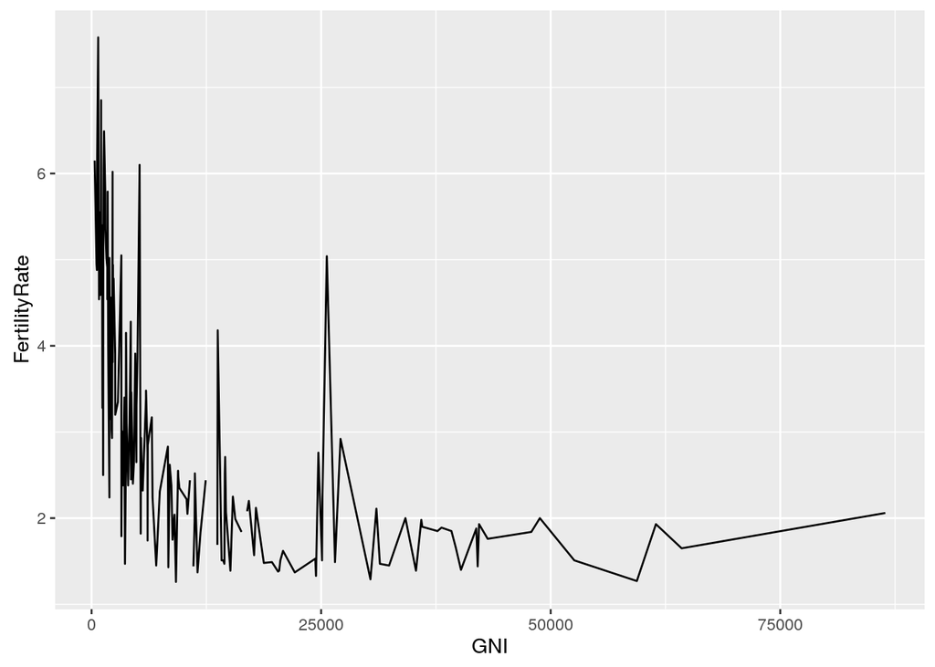

```r
scatterplot + geom_line()
```

Now, you can see a line graph in the Graphics window. However, a line doesn’t really make sense for this particular plot.

In addition to specifying that the geometry we want is points, we can add other options, like the color, shape, and size of the points.

Let’s redo our plot with blue triangles instead of circles.

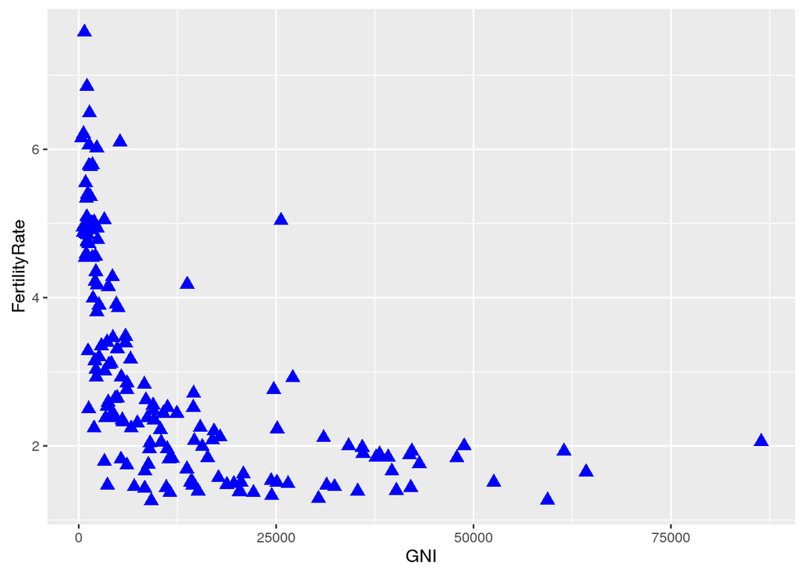

```r
scatterplot + geom_point(color="blue", size=3, shape=17)
```

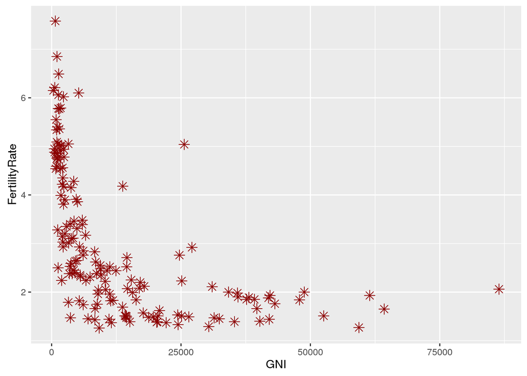

```r
scatterplot + geom_point(color="darkred", size=3, shape=8)
```

There are many different colors and shapes that you can specify.

Now, let’s add a title to the plot.

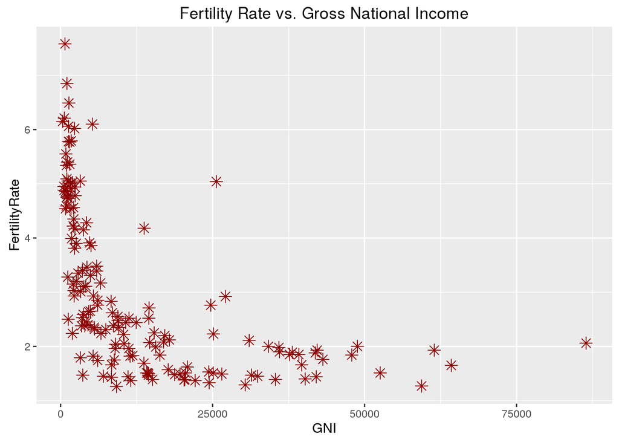

```r
scatterplot + geom_point(color="darkred", size=3, shape=8) +
  ggtitle("Fertility Rate vs. Gross National Income")
```

You should now see that it has a nice title at the top.

Now, let’s save our plot to a file.

We can do this by first saving our plot to a variable.

```r
fertilityGNIplot = scatterplot + geom_point(color="darkred", size=3, shape=8) +
  ggtitle("Fertility Rate vs. Gross National Income")
```

This will save our scatterplot to the variable, fertilityGNIplot.

Now, let’s create a file we want to save our plot to. We can do that with the pdf function.

```r
pdf("MyPlot.pdf")
print(fertilityGNIplot)
dev.off() # to close the file
```

Now, if you look at the folder where WHO.csv is, you should see another file called MyPlot.pdf, containing the plot we made.

### Advanced Scatterplots Using ggplot

Let’s color the points by region instead. This time, we want to add a color option to our aesthetic, since we’re assigning a variable in our data set to the colors.

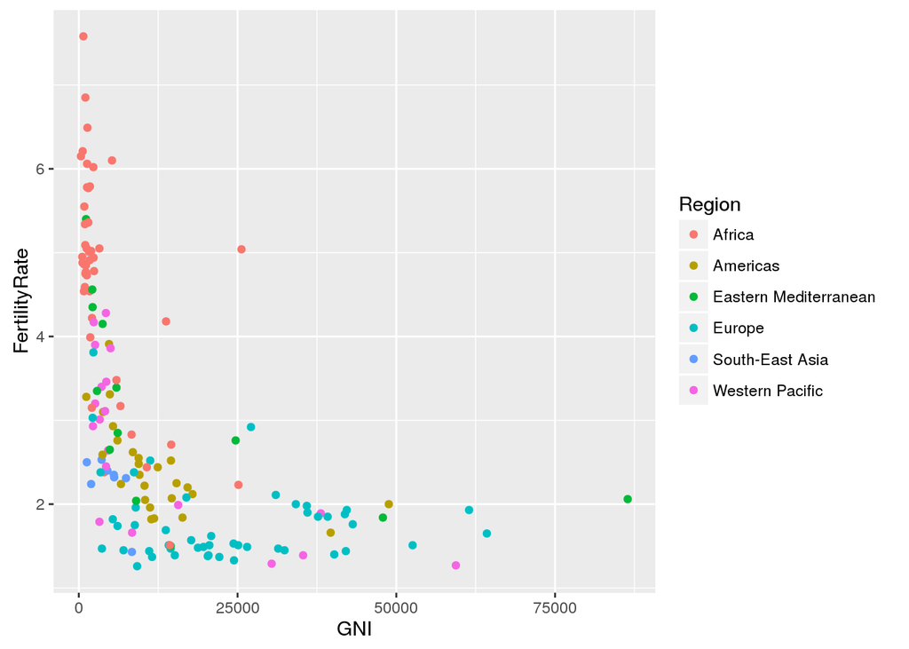

```r
ggplot(WHO, aes(x = GNI, y = FertilityRate, color=Region)) + geom_point()
```

Now, in the plot, we should see that each point is colored corresponding to the region that country belongs in.

So the countries in Africa are colored red, the countries in the Americas are colored gold, the countries in the Eastern Mediterranean are colored green, etc.

This really helps us see something that we didn’t see before. The points from the different regions are really located in different areas on the plot.

Let’s now instead color the points according to the country’s life expectancy.

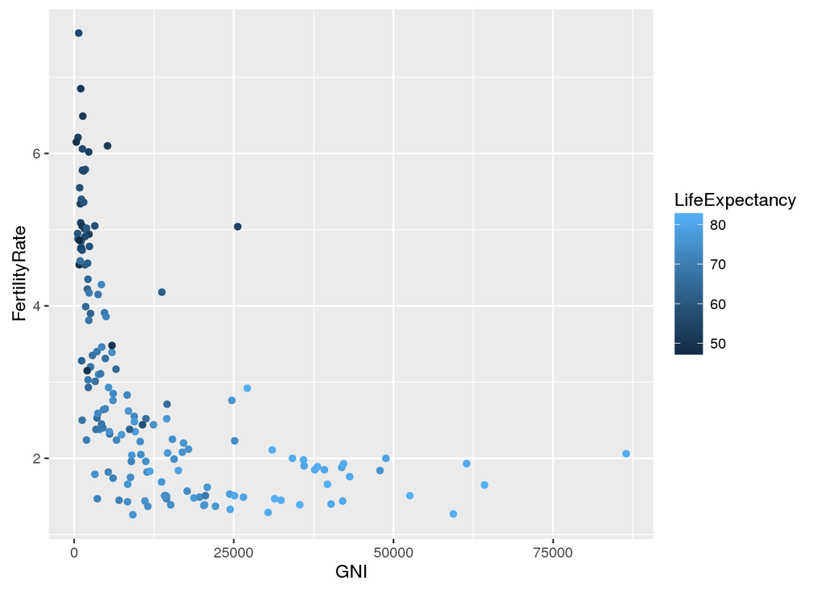

```r
ggplot(WHO, aes(x = GNI, y = FertilityRate, color=LifeExpectancy)) + geom_point()
```

Now, we should see that each point is colored according to the life expectancy in that country.

Here, we’re coloring by LifeExpectancy instead, which is a numerical variable, so we get a gradient of colors. Lighter blue corresponds to a higher life expectancy, and darker blue corresponds to a lower life expectancy.

Let’s take a look at a different plot now. Suppose we were interested in seeing whether the fertility rate of a country was a good predictor of the percentage of the population under 15. Intuitively, we would expect these variables to be highly correlated. But before trying any statistical models, let’s explore our data with a plot.

So now, let’s use the ggplot function on the WHO data again, but we’re going to specify in our aesthetic that the x variable should be FertilityRate, and the y variable should be the variable, Under15.

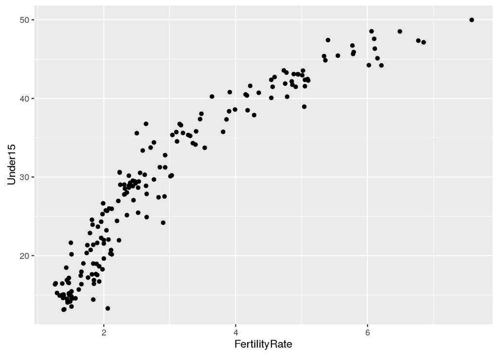

```r
ggplot(WHO, aes(x = FertilityRate, y = Under15)) + geom_point()
```

This is really interesting. It looks like the variables are certainly correlated, but as the fertility rate increases, the variable, Under15 starts increasing less. So this doesn’t really look like a linear relationship.

But we suspect that a log transformation of FertilityRate will be better. Let’s give it a shot.

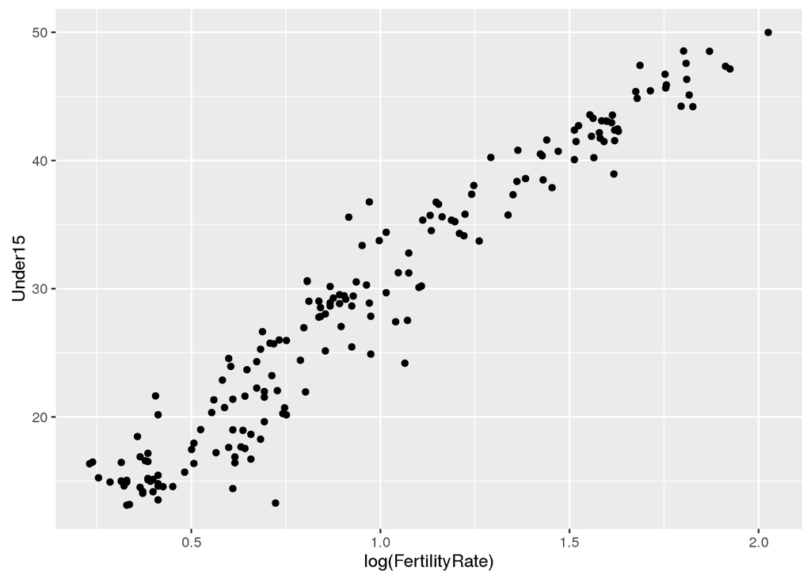

```r
ggplot(WHO, aes(x = log(FertilityRate), y = Under15)) + geom_point()
```

Now this looks like a linear relationship. Let’s try building in a simple linear regression model to predict the percentage of the population under 15, using the log of the fertility rate.

```r
model = lm(Under15 ~ log(FertilityRate), data = WHO)
summary(model)
```

```
##
## Call:
## lm(formula = Under15 ~ log(FertilityRate), data = WHO)
##
## Residuals:
##      Min       1Q   Median       3Q      Max
## -10.3131  -1.7742   0.0446   1.7440   7.7174
##
## Coefficients:
##                    Estimate Std. Error t value Pr(>|t|)
## (Intercept)          7.6540     0.4478   17.09   <2e-16 ***
## log(FertilityRate)  22.0547     0.4175   52.82   <2e-16 ***
## ---
## Signif. codes:  0 '***' 0.001 '**' 0.01 '*' 0.05 '.' 0.1 ' ' 1
##
## Residual standard error: 2.65 on 181 degrees of freedom
##   (11 observations deleted due to missingness)
## Multiple R-squared:  0.9391, Adjusted R-squared:  0.9387
## F-statistic:  2790 on 1 and 181 DF,  p-value: < 2.2e-16
```

It looks like the log of FertilityRate is indeed a great predictor of Under15. The variable is highly significant, and our R-squared is 0.9391.

Visualization was a great way for us to realize that the log transformation would be better. If we instead had just used the FertilityRate, the R-squared would have been 0.87. That’s a pretty significant decrease in R-squared.

So now, let’s add this regression line to our plot. This is pretty easy in ggplot. We just have to add another layer.

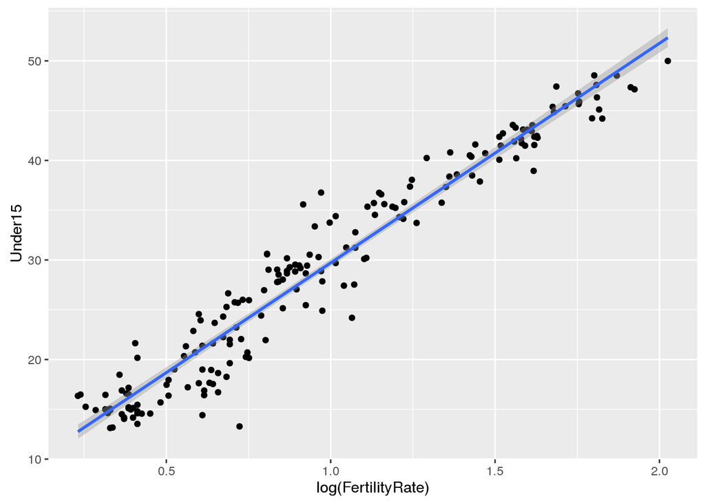

```r
ggplot(WHO, aes(x = log(FertilityRate), y = Under15)) + geom_point() + stat_smooth(method="lm")
```

Now, you should see a blue line going through the data. This is our regression line. By default, ggplot will draw a 95% confidence interval shaded around the line. We can change this by specifying options within the statistics layer.

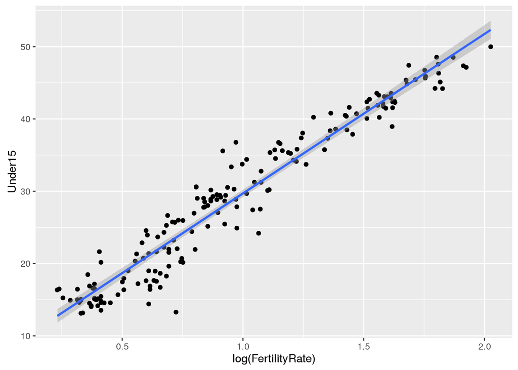

```r
ggplot(WHO, aes(x = log(FertilityRate), y = Under15)) + geom_point() + stat_smooth(method="lm", level=0.99)
```

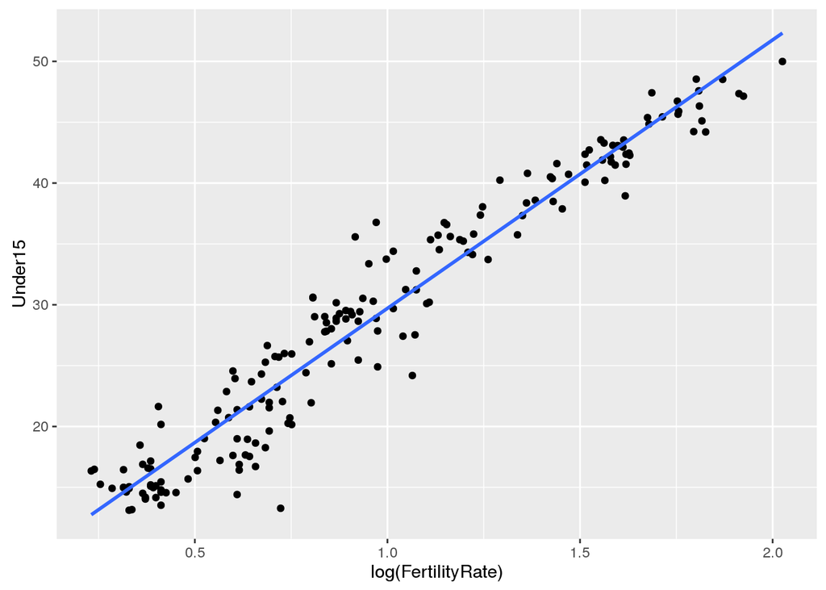

```r
ggplot(WHO, aes(x = log(FertilityRate), y = Under15)) + geom_point() + stat_smooth(method="lm", se = FALSE)
```

Now, we just have the regression line in blue. We could also change the color of the regression line by typing as an option, color = “orange”.

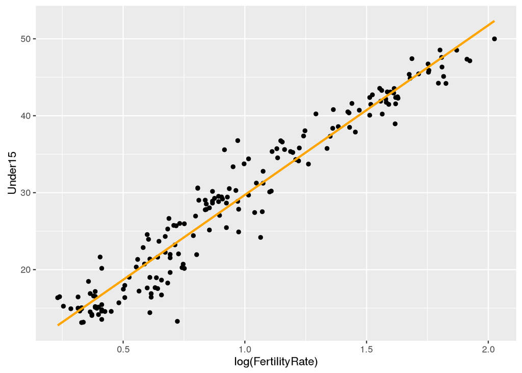

```r
ggplot(WHO, aes(x = log(FertilityRate), y = Under15)) + geom_point() + stat_smooth(method="lm", se = FALSE, color="orange")
```

Now, we have an orange linear regression line.

As we’ve seen in this lecture, scatterplots are great for exploring data. However, there are many other ways to represent data visually, such as box plots, line charts, histograms, heat maps, and geographic maps.

In some cases, it may be better to choose one of these other ways of visualizing your data.

Luckily, ggplot makes it easy to go from one type of visualization to another, simply by adding the appropriate layer to the plot.

So what is the edge of visualizations?

The WHO data that we used here is used by citizens, policymakers, and organizations around the world.

Visualizing the data facilitates the of global health trends at a glance.

By using ggplot in R, we’re able to visualize data for exploration, modeling, and sharing analytics results.